# Baltimore County 911 Overdose Calls Analysis

Lucy Scothern

# Z-Score Analysis of Baltimore County 911 Calls

## Introduction

In this analysis, we’ll examine data on 911 drug overdose calls from Baltimore County to identify unusually busy or quiet days using z-scores. By calculating the number of calls per day and analyzing their statistical distribution, we can determine which days experienced an abnormal volume of emergency calls - information that could lead to potential story ideas.

A z-score measures how many standard deviations a data point is from the mean. Generally: - Z-scores between -2 and 2 represent typical values (about 95% of the data) - Z-scores beyond ±2 indicate unusual values that warrant investigation - Z-scores beyond ±3 are very unusual (only about 0.3% of normally distributed data)

## Task 1: Setup and Data Loading

Let’s start by loading the necessary packages and our dataset:

```r
library(tidyverse)  # For data manipulation and visualization
library(lubridate)  # For handling dates
library(knitr)      # For nice tables
library(scales)     # For better axis formatting
```

```r
# Load the 911 calls data
calls_data <- read_csv("https://raw.githubusercontent.com/dwillis/datajournalismbook-maryland/refs/heads/main/data/baltco_911_calls.csv")

# Display the first few rows to understand the structure
head(calls_data)
```

```
## # A tibble: 6 × 4
##   date       time     callnumber address
##   <date>     <time>        <dbl> <chr>
## 1 2022-02-06 09:49:02  220370885 4113 HANWELL RD
## 2 2022-02-06 13:21:09  220371233 15 HOGARTH CI
## 3 2022-02-06 14:08:18  220371291 5440 MONTBEL AV
## 4 2022-02-06 15:50:09  220371448 8368 CHURCH LA
## 5 2022-02-06 15:52:52  220371454 1015 DONINGTON CI
## 6 2022-02-06 18:46:40  220371741 1126 ENGLEBERTH RD
```

## Task 2: Initial Data Exploration

Let’s explore the basic structure and characteristics of our dataset:

```r
# Get a summary of the data
glimpse(calls_data)
```

```
## Rows: 3,822
## Columns: 4
## $ date       <date> 2022-02-06, 2022-02-06, 2022-02-06, 2022-02-06, 2022-02-06…
## $ time       <time> 09:49:02, 13:21:09, 14:08:18, 15:50:09, 15:52:52, 18:46:40…
## $ callnumber <dbl> 220370885, 220371233, 220371291, 220371448, 220371454, 2203…
## $ address    <chr> "4113 HANWELL RD", "15 HOGARTH CI", "5440 MONTBEL AV", "836…
```

```r
# Check for any missing values
colSums(is.na(calls_data))
```

```
##       date       time callnumber    address
##          0          0          0          0
```

```r
# Check the date range in our data
min_date <- min(calls_data$date)
max_date <- max(calls_data$date)
cat("Data ranges from", min_date, "to", max_date)
```

```
## Data ranges from 19029 to 19394
```

## Task 3: Aggregating Calls by Day (3 points)

Now let’s count how many 911 overdose calls occurred on each day:

```r
# Count calls per day
daily_calls <- calls_data |>
  count(date, name = "call_count")

# Display the first few days
head(daily_calls, 10) |>
  kable()
```

| date | call_count |
| --- | --- |
| 2022-02-06 | 8 |
| 2022-02-07 | 15 |
| 2022-02-08 | 7 |
| 2022-02-09 | 5 |
| 2022-02-10 | 5 |
| 2022-02-11 | 8 |
| 2022-02-12 | 9 |
| 2022-02-13 | 7 |
| 2022-02-14 | 11 |
| 2022-02-15 | 7 |

```r
# Basic summary statistics for daily call volume
summary(daily_calls$call_count)
```

```
##    Min. 1st Qu.  Median    Mean 3rd Qu.    Max.
##    1.00    8.00   10.00   10.44   13.00   23.00
```

Let’s visualize the time series of daily calls. What patterns do you see? If you had to draw horizontal lines that would highlight unusual days, where would those lines be?

Most days have a cluster with a consistent range. There are some spikes where the number of calls is noticeably higher- most values fall within a middle range.To highlight unusual days, horizontal lines could be placed just outside the typical range. This would help me to visually spot outliers quickly before confirming them with z-scores.

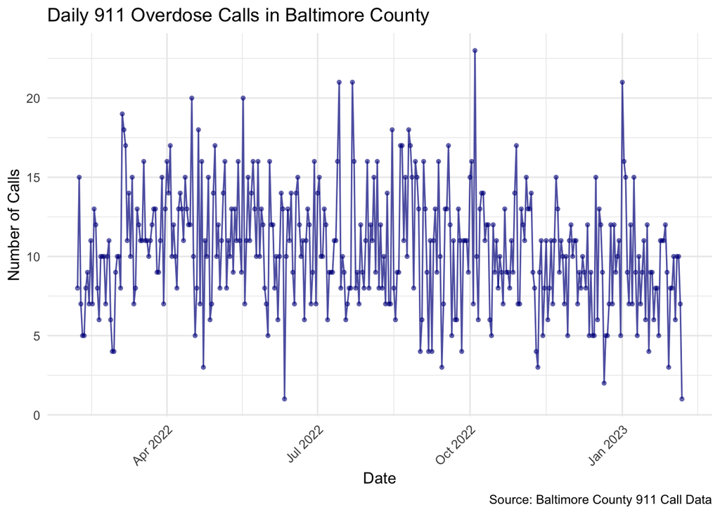

```r
# Plot daily call volume
ggplot(daily_calls, aes(x = date, y = call_count)) +
  geom_line(color = "darkblue", alpha = 0.7) +
  geom_point(color = "darkblue", alpha = 0.5, size = 1) +
  theme_minimal() +
  labs(title = "Daily 911 Overdose Calls in Baltimore County",
       x = "Date",
       y = "Number of Calls",
       caption = "Source: Baltimore County 911 Call Data") +
  scale_y_continuous(labels = comma) +
  theme(axis.text.x = element_text(angle = 45, hjust = 1))
```

## Task 4: Calculating Z-Scores for Daily Call Volume

Now, let’s calculate z-scores to identify statistically unusual days:

```r
# Calculate z-scores for daily call counts
daily_calls <- daily_calls |>
  mutate(
    mean_calls = mean(call_count),
    sd_calls = sd(call_count),
    z_score = (call_count - mean_calls) / sd_calls
  )

# Display the data with z-scores
daily_calls |>
  select(date, call_count, z_score) |>
  head(10) |>
  kable(digits = 2)
```

| date | call_count | z_score |
| --- | --- | --- |
| 2022-02-06 | 8 | -0.66 |
| 2022-02-07 | 15 | 1.23 |
| 2022-02-08 | 7 | -0.93 |
| 2022-02-09 | 5 | -1.47 |
| 2022-02-10 | 5 | -1.47 |
| 2022-02-11 | 8 | -0.66 |
| 2022-02-12 | 9 | -0.39 |
| 2022-02-13 | 7 | -0.93 |
| 2022-02-14 | 11 | 0.15 |
| 2022-02-15 | 7 | -0.93 |

## Task 5: Identifying Unusual Days (3 points)

Let’s identify days with unusually high or low call volumes (|z-score| > 2):

```r
# Find days with unusual call volumes
unusual_days <- daily_calls |>
  filter(abs(z_score) > 2) |>
  arrange(desc(abs(z_score)))

# Display unusual days
unusual_days |>
  select(date, call_count, z_score) |>
  kable(digits = 2)
```

| date | call_count | z_score |
| --- | --- | --- |
| 2022-10-04 | 23 | 3.39 |
| 2022-07-14 | 21 | 2.85 |
| 2022-07-22 | 21 | 2.85 |
| 2023-01-01 | 21 | 2.85 |
| 2022-04-16 | 20 | 2.58 |
| 2022-05-17 | 20 | 2.58 |
| 2022-06-11 | 1 | -2.55 |
| 2023-02-06 | 1 | -2.55 |
| 2022-03-05 | 19 | 2.31 |
| 2022-12-21 | 2 | -2.28 |
| 2022-03-06 | 18 | 2.04 |
| 2022-04-20 | 18 | 2.04 |
| 2022-08-15 | 18 | 2.04 |
| 2022-08-25 | 18 | 2.04 |
| 2022-04-23 | 3 | -2.01 |
| 2022-09-14 | 3 | -2.01 |
| 2022-11-11 | 3 | -2.01 |
| 2023-01-29 | 3 | -2.01 |

```r
# Count how many days were unusually busy vs. unusually quiet
unusual_days |>
  group_by(unusual_type = if_else(z_score > 0, "Unusually High", "Unusually Low")) |>
  summarise(count = n()) |>
  kable()
```

| unusual_type | count |
| --- | --- |
| Unusually High | 11 |
| Unusually Low | 7 |

Let’s visualize these unusual days in the context of the full dataset. How do they differ from your answer on Task 3?

The unusual days stand out more clearly than in the visual estimates from Task 3. The z-score calculation identifies which days are unusual (beyond +2 sds). Some of the spikes I can see visually are confirmed as unusually high call days, while others that looked high may still fall within the normal range. Using z-scores provides a more accurate way to identify unusual days.

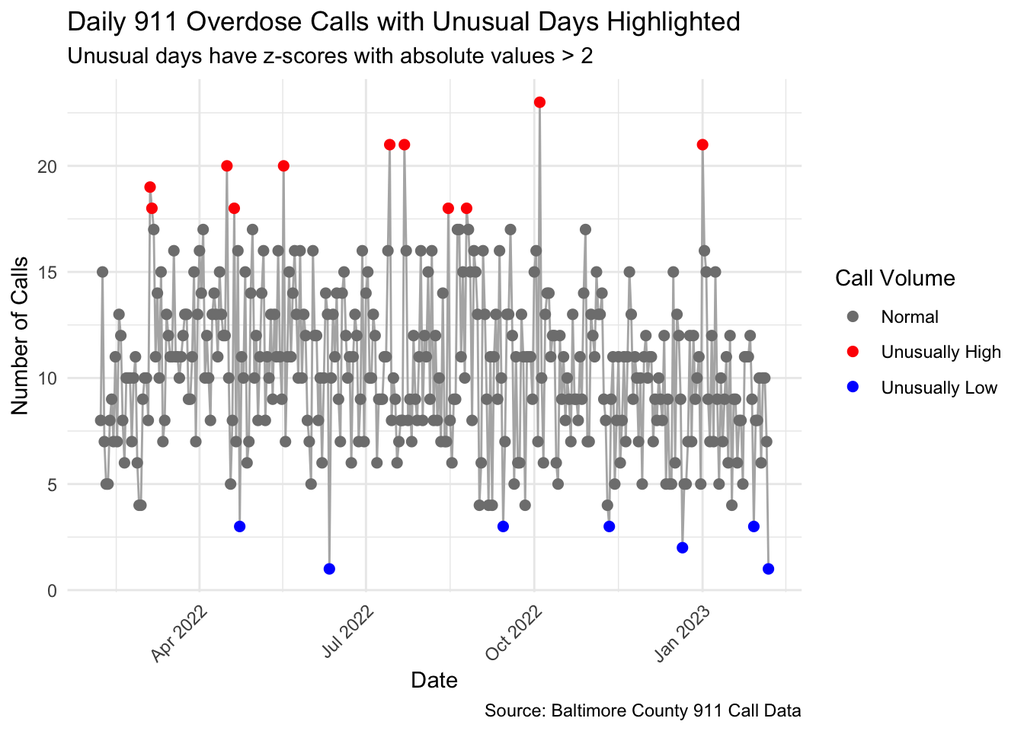

```r
# Create a clean factor for the plot legend
daily_calls <- daily_calls |>
  mutate(call_volume_type = case_when(
    z_score > 2 ~ "Unusually High",
    z_score < -2 ~ "Unusually Low",
    TRUE ~ "Normal"
  ))

# Plot with unusual days highlighted
ggplot(daily_calls, aes(x = date, y = call_count, color = call_volume_type)) +
  geom_line(color = "gray70") +
  geom_point(size = 2) +
  scale_color_manual(values = c("Normal" = "gray50",
                               "Unusually High" = "red",
                               "Unusually Low" = "blue")) +
  theme_minimal() +
  labs(title = "Daily 911 Overdose Calls with Unusual Days Highlighted",
       subtitle = "Unusual days have z-scores with absolute values > 2",
       x = "Date",
       y = "Number of Calls",
       color = "Call Volume",
       caption = "Source: Baltimore County 911 Call Data") +
  scale_y_continuous(labels = comma) +
  theme(axis.text.x = element_text(angle = 45, hjust = 1))
```

## Task 6: Day of Week Patterns

Let’s also check if certain days of the week typically see more 911 calls:

```r
# Add day of week to our dataset
daily_calls <- daily_calls |>
  mutate(
    day_of_week = wday(date, label = TRUE)
  )

# Calculate average calls by day of week
dow_summary <- daily_calls |>
  group_by(day_of_week) |>
  summarise(
    avg_calls = mean(call_count),
    median_calls = median(call_count),
    min_calls = min(call_count),
    max_calls = max(call_count)
  ) |>
  arrange(match(day_of_week, c("Mon", "Tue", "Wed", "Thu", "Fri", "Sat", "Sun")))

# Display summary by day of week
dow_summary |> kable(digits = 1)
```

| day_of_week | avg_calls | median_calls | min_calls | max_calls |
| --- | --- | --- | --- | --- |
| Mon | 10.1 | 10 | 1 | 18 |
| Tue | 10.3 | 10 | 4 | 23 |
| Wed | 10.1 | 10 | 2 | 18 |
| Thu | 9.4 | 9 | 4 | 21 |
| Fri | 11.0 | 11 | 3 | 21 |
| Sat | 11.3 | 11 | 1 | 20 |
| Sun | 10.8 | 10 | 3 | 21 |

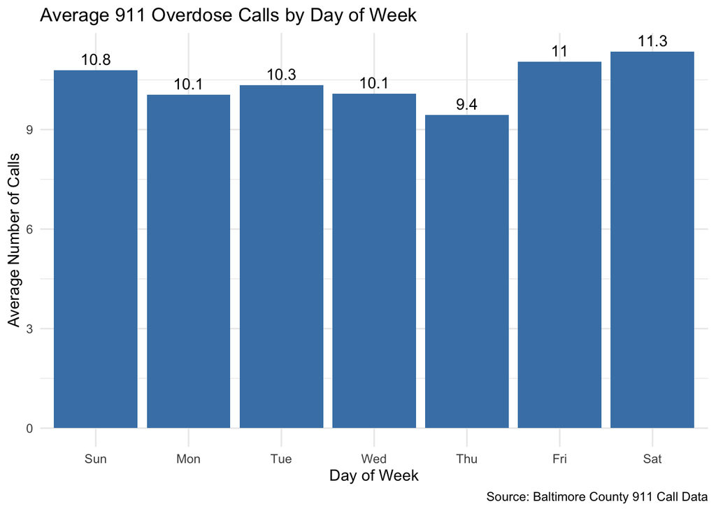

```r
# Plot calls by day of week
ggplot(dow_summary, aes(x = day_of_week, y = avg_calls)) +
  geom_col(fill = "steelblue") +
  geom_text(aes(label = round(avg_calls, 1)), vjust = -0.5) +
  theme_minimal() +
  labs(title = "Average 911 Overdose Calls by Day of Week",
       x = "Day of Week",
       y = "Average Number of Calls",
       caption = "Source: Baltimore County 911 Call Data") +
  theme(axis.text.x = element_text(angle = 0))
```

## Task 7: Accounting for Day of Week Pattern (3 points)

We can also calculate z-scores that account for the day of the week pattern. How would you describe the day with the highest z-score without using the term “z-score”?

I would call this day the most abnormally high/low day of the year for calls.

```r
# Calculate day-of-week adjusted z-scores
daily_calls <- daily_calls |>
  group_by(day_of_week) |>
  mutate(
    dow_mean = mean(call_count),
    dow_sd = sd(call_count),
    dow_z_score = (call_count - dow_mean) / dow_sd
  ) |>
  ungroup()

# Find days that were unusual for their day of the week
dow_unusual_days <- daily_calls |>
  filter(abs(dow_z_score) > 2) |>
  arrange(desc(abs(dow_z_score)))

# Display days that were unusual for their day of the week
dow_unusual_days |>
  select(date, day_of_week, call_count, dow_mean, dow_z_score) |>
  kable(digits = 2)
```

| date | day_of_week | call_count | dow_mean | dow_z_score |
| --- | --- | --- | --- | --- |
| 2022-10-04 | Tue | 23 | 10.35 | 3.31 |
| 2022-07-14 | Thu | 21 | 9.44 | 3.09 |
| 2023-01-01 | Sun | 21 | 10.79 | 2.78 |
| 2022-07-22 | Fri | 21 | 11.04 | 2.72 |
| 2022-12-21 | Wed | 2 | 10.08 | -2.59 |
| 2022-04-20 | Wed | 18 | 10.08 | 2.54 |
| 2022-06-11 | Sat | 1 | 11.35 | -2.53 |
| 2022-05-17 | Tue | 20 | 10.35 | 2.52 |
| 2023-02-06 | Mon | 1 | 10.06 | -2.51 |
| 2022-08-25 | Thu | 18 | 9.44 | 2.29 |
| 2022-09-14 | Wed | 3 | 10.08 | -2.27 |
| 2022-08-15 | Mon | 18 | 10.06 | 2.20 |
| 2022-11-11 | Fri | 3 | 11.04 | -2.20 |
| 2023-01-29 | Sun | 3 | 10.79 | -2.12 |
| 2022-04-16 | Sat | 20 | 11.35 | 2.12 |
| 2022-04-23 | Sat | 3 | 11.35 | -2.04 |

## Task 8: Temporal Patterns and Trends

Let’s also look for seasonal patterns or trends over time:

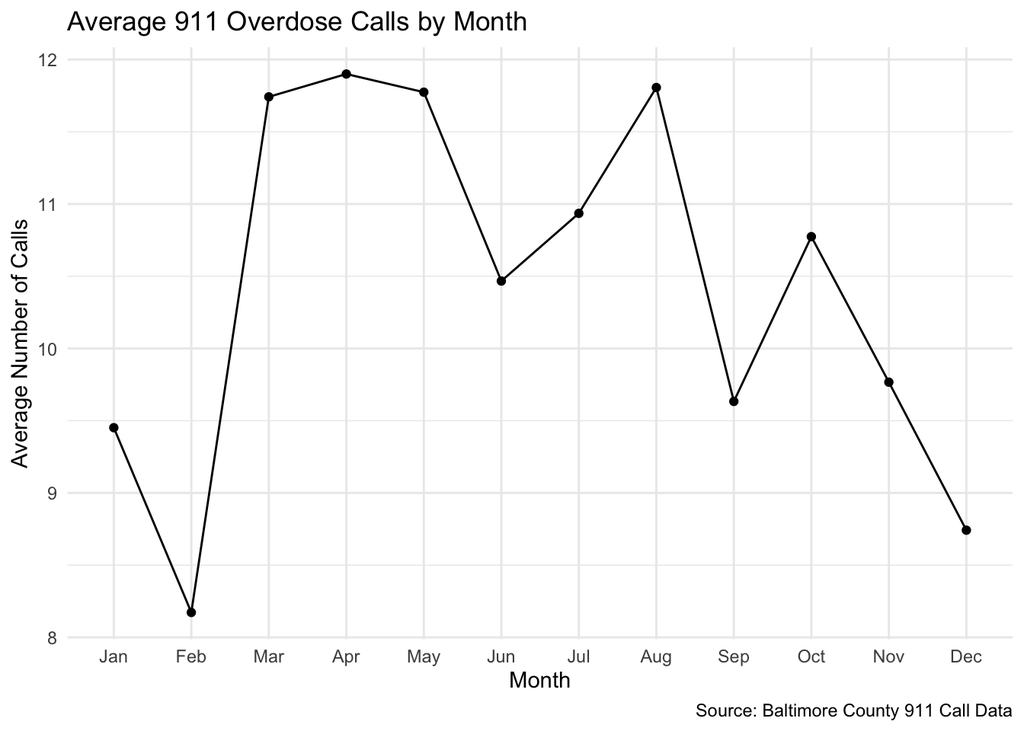

```r
# Add month and year for seasonal analysis
daily_calls <- daily_calls |>
  mutate(
    month = month(date, label = TRUE),
    year = year(date)
  )

# Calculate average calls by month
monthly_summary <- daily_calls |>
  group_by(month) |>
  summarise(
    avg_calls = mean(call_count),
    median_calls = median(call_count)
  )

# Plot calls by month
ggplot(monthly_summary, aes(x = month, y = avg_calls, group = 1)) +
  geom_line() +
  geom_point() +
  theme_minimal() +
  labs(title = "Average 911 Overdose Calls by Month",
       x = "Month",
       y = "Average Number of Calls",
       caption = "Source: Baltimore County 911 Call Data")
```

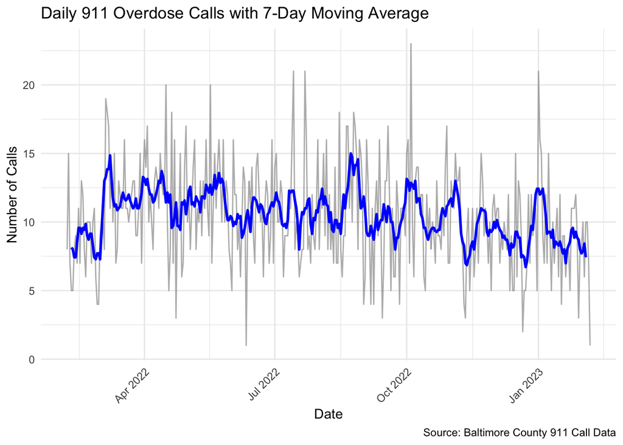

```r
# Show a rolling 7-day average to better see trends
daily_calls <- daily_calls |>
  arrange(date) |>
  mutate(rolling_avg_7day = zoo::rollmean(call_count, k = 7, fill = NA))

# Plot with 7-day rolling average
ggplot(daily_calls, aes(x = date)) +
  geom_line(aes(y = call_count), color = "gray60", alpha = 0.7) +
  geom_line(aes(y = rolling_avg_7day), color = "blue", size = 1) +
  theme_minimal() +
  labs(title = "Daily 911 Overdose Calls with 7-Day Moving Average",
       x = "Date",
       y = "Number of Calls",
       caption = "Source: Baltimore County 911 Call Data") +
  theme(axis.text.x = element_text(angle = 45, hjust = 1))
```

## Task 9: T Most Unusual Days

For the most unusual days, we might want to check if they coincide with significant events:

```r
# Get the top 10 most unusual days
top_outliers <- daily_calls |>
  arrange(desc(abs(z_score))) |>
  head(10) |>
  select(date, day_of_week, call_count, z_score)

# Display these days
top_outliers |> kable(digits = 2)
```

| date | day_of_week | call_count | z_score |
| --- | --- | --- | --- |
| 2022-10-04 | Tue | 23 | 3.39 |
| 2022-07-14 | Thu | 21 | 2.85 |
| 2022-07-22 | Fri | 21 | 2.85 |
| 2023-01-01 | Sun | 21 | 2.85 |
| 2022-04-16 | Sat | 20 | 2.58 |
| 2022-05-17 | Tue | 20 | 2.58 |
| 2022-06-11 | Sat | 1 | -2.55 |
| 2023-02-06 | Mon | 1 | -2.55 |
| 2022-03-05 | Sat | 19 | 2.31 |
| 2022-12-21 | Wed | 2 | -2.28 |

## Task 10: Journalistic Insights (6 points)

Based on our z-score analysis, what are some potential angles for reporting? What would your next steps be and what would you tell an editor about your findings?

I would tell my editor that the data shows clear spikes in overdose-related 911 calls that stand out. These stats could lead to further reporting on what caused them and how the county responds to the surges.